# Producing Effective Tables in R

# Packages in this presentation

```r
library(broom)
library(dplyr)
library(ggplot2)
library(magrittr)
library(reshape2)
library(tidyr)

library(knitr)
library(xtable)
library(pixiedust)
library(nnet)
options(pixiedust_print_method = "html")
```

# Table Construction: Guiding Principles

1. Avoid trying to use tables the way you would a graph.
2. If your table requires a legend, it’s too complicated. Use a graph instead.
3. Background colors should only be used for row or group discrimination (with very rare exceptions).
4. Subtlety is a virtue.
5. When using color (backgrounds, fonts, or borders), try to limit yourself to two colors.

# Table Construction: Core Concepts

1. Result Emphasis
2. Row Discrimination
3. Grouping
4. Sectioning

# Result Emphasis

- The concept of *subtly* drawing attention to the result you want the reader to focus on.
- Please note the differnce between *subtlety* and *SUBTLETY*

# Result Emphasis

Your best options for drawing attention to results is to use either *italic* or **bold**. Don’t use both.

Table 1: Who Shot First by Self Declared Fan Status

| Who Shot First? | No | Yes |
| --- | --- | --- |
| Greedo | 46 (16.2%) | 151 (27.4%) |
| Han | 57 (20.1%) | 268 (48.6%) |
| I don't understand this question | 180 (63.4%) | 126 (22.8%) |
| NA | 1 (0.4%) | 7 (1.3%) |

# Result Emphasis

Table 2: Who Shot First by Self Declared Fan Status

| Who Shot First? | No | Yes |
| --- | --- | --- |
| Greedo | 46 (16.2%) | 151 (27.4%) |
| Han | 57 (20.1%) | 268 (48.6%) |
| I don't understand this question | 180 (63.4%) | 126 (22.8%) |
| NA | 1 (0.4%) | 7 (1.3%) |

# Result Emphasis

Table 3: Logistic Regression for Perceiving Jar-Jar Binks Favorably

| Term | Level | Estimate | SE | Z | P-value |
| --- | --- | --- | --- | --- | --- |
| Intercept |  | 0.9 | 0.2 | -0.53 | 0.6 |
| age | 30-44 vs. 18-29 | 0.8 | 0.25 | -0.89 | 0.38 |
| age | 45-60 vs. 18-29 | 1.62 | 0.24 | 1.98 | 0.047 |
| age | > 60 vs. 18-29 | 2.54 | 0.28 | 3.33 | < 0.001 |
| gender | Male vs. Female | 0.49 | 0.18 | -3.93 | < 0.001 |

# Result Emphasis

Table 4: Logistic Regression for Perceiving Jar-Jar Binks Favorably

| Term | Level | Estimate | SE | Z | P-value |
| --- | --- | --- | --- | --- | --- |
| Intercept |  | 0.9 | 0.2 | -0.53 | 0.6 |
| age | 30-44 vs. 18-29 | 0.8 | 0.25 | -0.89 | 0.38 |
| age | 45-60 vs. 18-29 | 1.62 | 0.24 | 1.98 | 0.047 |
| age | > 60 vs. 18-29 | 2.54 | 0.28 | 3.33 | < 0.001 |
| gender | Male vs. Female | 0.49 | 0.18 | -3.93 | < 0.001 |

# Result Emphasis (Violation of Subtlety Principle)

Table 5: Logistic Regression for Perceiving Jar-Jar Binks Favorably

| Term | Level | Estimate | SE | Z | P-value |
| --- | --- | --- | --- | --- | --- |
| Intercept |  | 0.9 | 0.2 | -0.53 | 0.6 |
| age | 30-44 vs. 18-29 | 0.8 | 0.25 | -0.89 | 0.38 |
| age | 45-60 vs. 18-29 | 1.62 | 0.24 | 1.98 | 0.047 |
| age | > 60 vs. 18-29 | 2.54 | 0.28 | 3.33 | < 0.001 |
| gender | Male vs. Female | 0.49 | 0.18 | -3.93 | < 0.001 |

# Result Emphasis (Violation of Subtlety Principle)

Table 6: Logistic Regression for Perceiving Jar-Jar Binks Favorably

| Term | Level | Estimate | SE | Z | P-value |
| --- | --- | --- | --- | --- | --- |
| Intercept |  | 0.9 | 0.2 | -0.53 | 0.6 |
| age | 30-44 vs. 18-29 | 0.8 | 0.25 | -0.89 | 0.38 |
| age | 45-60 vs. 18-29 | 1.62 | 0.24 | 1.98 | 0.047 |
| age | > 60 vs. 18-29 | 2.54 | 0.28 | 3.33 | < 0.001 |
| gender | Male vs. Female | 0.49 | 0.18 | -3.93 | < 0.001 |

# Result Emphasis (Violation of Subtlety Principle)

Table 7: Logistic Regression for Perceiving Jar-Jar Binks Favorably

| Term | Level | Estimate | SE | Z | P-value |
| --- | --- | --- | --- | --- | --- |
| Intercept |  | 0.9 | 0.2 | -0.53 | 0.6 |
| age | 30-44 vs. 18-29 | 0.8 | 0.25 | -0.89 | 0.38 |
| age | 45-60 vs. 18-29 | 1.62 | 0.24 | 1.98 | 0.047 |
| age | > 60 vs. 18-29 | 2.54 | 0.28 | 3.33 | < 0.001 |
| gender | Male vs. Female | 0.49 | 0.18 | -3.93 | < 0.001 |

**This is like typing in all CAPS. Don’t do it.**

# Row Discrimination

Two common strategies

1. Background striping
2. Borders

# Row Discrimination

Table 8: Frequency of Sleeping Separate

| sleep_separate | Divorced | In a domestic partnership or civil union | Married | Separated | Single, but cohabiting with a significant other | Widowed |
| --- | --- | --- | --- | --- | --- | --- |
|  | NA | NA | 10 | 1 | 2 | 1 |
| A few times per month | NA | 5 | 50 | NA | 7 | NA |
| A few times per week | 1 | 4 | 38 | NA | 3 | NA |
| Every night | 1 | 5 | 122 | 2 | 17 | NA |
| Never | 7 | 26 | 472 | 3 | 76 | 2 |
| Once a month or less | 3 | 3 | 73 | 2 | 20 | NA |
| Once a year or less | NA | 5 | 119 | NA | 13 | NA |

# Row Discrimination

Table 9: Frequency of Sleeping Separate

| sleep_separate | Divorced | In a domestic partnership or civil union | Married | Separated | Single, but cohabiting with a significant other | Widowed |
| --- | --- | --- | --- | --- | --- | --- |
|  | NA | NA | 10 | 1 | 2 | 1 |
| A few times per month | NA | 5 | 50 | NA | 7 | NA |
| A few times per week | 1 | 4 | 38 | NA | 3 | NA |
| Every night | 1 | 5 | 122 | 2 | 17 | NA |
| Never | 7 | 26 | 472 | 3 | 76 | 2 |
| Once a month or less | 3 | 3 | 73 | 2 | 20 | NA |
| Once a year or less | NA | 5 | 119 | NA | 13 | NA |

# Grouping

| .rownames | mpg | cyl | disp | hp | drat | wt | qsec | vs | am | gear | carb |
| --- | --- | --- | --- | --- | --- | --- | --- | --- | --- | --- | --- |
| AMC Javelin | 15.2 | 8 | 304 | 150 | 3.15 | 3.435 | 17.3 | 0 | 0 | 3 | 2 |
| Merc 240D | 24.4 | 4 | 146.7 | 62 | 3.69 | 3.19 | 20 | 1 | 0 | 4 | 2 |
| Merc 450SE | 16.4 | 8 | 275.8 | 180 | 3.07 | 4.07 | 17.4 | 0 | 0 | 3 | 3 |
| Datsun 710 | 22.8 | 4 | 108 | 93 | 3.85 | 2.32 | 18.61 | 1 | 1 | 4 | 1 |
| Porsche 914-2 | 26 | 4 | 120.3 | 91 | 4.43 | 2.14 | 16.7 | 0 | 1 | 5 | 2 |
| Mazda RX4 | 21 | 6 | 160 | 110 | 3.9 | 2.62 | 16.46 | 0 | 1 | 4 | 4 |
| Cadillac Fleetwood | 10.4 | 8 | 472 | 205 | 2.93 | 5.25 | 17.98 | 0 | 0 | 3 | 4 |
| Toyota Corolla | 33.9 | 4 | 71.1 | 65 | 4.22 | 1.835 | 19.9 | 1 | 1 | 4 | 1 |
| Toyota Corona | 21.5 | 4 | 120.1 | 97 | 3.7 | 2.465 | 20.01 | 1 | 0 | 3 | 1 |
| Lotus Europa | 30.4 | 4 | 95.1 | 113 | 3.77 | 1.513 | 16.9 | 1 | 1 | 5 | 2 |
| Fiat X1-9 | 27.3 | 4 | 79 | 66 | 4.08 | 1.935 | 18.9 | 1 | 1 | 4 | 1 |
| Honda Civic | 30.4 | 4 | 75.7 | 52 | 4.93 | 1.615 | 18.52 | 1 | 1 | 4 | 2 |
| Fiat 128 | 32.4 | 4 | 78.7 | 66 | 4.08 | 2.2 | 19.47 | 1 | 1 | 4 | 1 |
| Merc 280C | 17.8 | 6 | 167.6 | 123 | 3.92 | 3.44 | 18.9 | 1 | 0 | 4 | 4 |
| Camaro Z28 | 13.3 | 8 | 350 | 245 | 3.73 | 3.84 | 15.41 | 0 | 0 | 3 | 4 |
| Duster 360 | 14.3 | 8 | 360 | 245 | 3.21 | 3.57 | 15.84 | 0 | 0 | 3 | 4 |
| Valiant | 18.1 | 6 | 225 | 105 | 2.76 | 3.46 | 20.22 | 1 | 0 | 3 | 1 |
| Merc 230 | 22.8 | 4 | 140.8 | 95 | 3.92 | 3.15 | 22.9 | 1 | 0 | 4 | 2 |
| Merc 450SL | 17.3 | 8 | 275.8 | 180 | 3.07 | 3.73 | 17.6 | 0 | 0 | 3 | 3 |
| Dodge Challenger | 15.5 | 8 | 318 | 150 | 2.76 | 3.52 | 16.87 | 0 | 0 | 3 | 2 |
| Mazda RX4 Wag | 21 | 6 | 160 | 110 | 3.9 | 2.875 | 17.02 | 0 | 1 | 4 | 4 |
| Chrysler Imperial | 14.7 | 8 | 440 | 230 | 3.23 | 5.345 | 17.42 | 0 | 0 | 3 | 4 |
| Pontiac Firebird | 19.2 | 8 | 400 | 175 | 3.08 | 3.845 | 17.05 | 0 | 0 | 3 | 2 |
| Hornet Sportabout | 18.7 | 8 | 360 | 175 | 3.15 | 3.44 | 17.02 | 0 | 0 | 3 | 2 |
| Volvo 142E | 21.4 | 4 | 121 | 109 | 4.11 | 2.78 | 18.6 | 1 | 1 | 4 | 2 |
| Merc 450SLC | 15.2 | 8 | 275.8 | 180 | 3.07 | 3.78 | 18 | 0 | 0 | 3 | 3 |
| Maserati Bora | 15 | 8 | 301 | 335 | 3.54 | 3.57 | 14.6 | 0 | 1 | 5 | 8 |
| Ford Pantera L | 15.8 | 8 | 351 | 264 | 4.22 | 3.17 | 14.5 | 0 | 1 | 5 | 4 |
| Ferrari Dino | 19.7 | 6 | 145 | 175 | 3.62 | 2.77 | 15.5 | 0 | 1 | 5 | 6 |
| Hornet 4 Drive | 21.4 | 6 | 258 | 110 | 3.08 | 3.215 | 19.44 | 1 | 0 | 3 | 1 |
| Lincoln Continental | 10.4 | 8 | 460 | 215 | 3 | 5.424 | 17.82 | 0 | 0 | 3 | 4 |
| Merc 280 | 19.2 | 6 | 167.6 | 123 | 3.92 | 3.44 | 18.3 | 1 | 0 | 4 | 4 |

# Grouping

Table 17: Vehicular Data Sorted by Gear and MPG with Background Toggling (still not ideal)

| .rownames | mpg | cyl | disp | hp | drat | wt | qsec | vs | am | gear | carb |
| --- | --- | --- | --- | --- | --- | --- | --- | --- | --- | --- | --- |
| 1 | 10.4 | 8 | 472 | 205 | 2.93 | 5.25 | 17.98 | 0 | 0 | 3 | 4 |
| 2 | 10.4 | 8 | 460 | 215 | 3 | 5.424 | 17.82 | 0 | 0 | 3 | 4 |
| 3 | 13.3 | 8 | 350 | 245 | 3.73 | 3.84 | 15.41 | 0 | 0 | 3 | 4 |
| 4 | 14.3 | 8 | 360 | 245 | 3.21 | 3.57 | 15.84 | 0 | 0 | 3 | 4 |
| 5 | 14.7 | 8 | 440 | 230 | 3.23 | 5.345 | 17.42 | 0 | 0 | 3 | 4 |
| 6 | 15.2 | 8 | 304 | 150 | 3.15 | 3.435 | 17.3 | 0 | 0 | 3 | 2 |
| 7 | 15.2 | 8 | 275.8 | 180 | 3.07 | 3.78 | 18 | 0 | 0 | 3 | 3 |
| 8 | 15.5 | 8 | 318 | 150 | 2.76 | 3.52 | 16.87 | 0 | 0 | 3 | 2 |
| 9 | 16.4 | 8 | 275.8 | 180 | 3.07 | 4.07 | 17.4 | 0 | 0 | 3 | 3 |
| 10 | 17.3 | 8 | 275.8 | 180 | 3.07 | 3.73 | 17.6 | 0 | 0 | 3 | 3 |
| 11 | 18.1 | 6 | 225 | 105 | 2.76 | 3.46 | 20.22 | 1 | 0 | 3 | 1 |
| 12 | 18.7 | 8 | 360 | 175 | 3.15 | 3.44 | 17.02 | 0 | 0 | 3 | 2 |
| 13 | 19.2 | 8 | 400 | 175 | 3.08 | 3.845 | 17.05 | 0 | 0 | 3 | 2 |
| 14 | 21.4 | 6 | 258 | 110 | 3.08 | 3.215 | 19.44 | 1 | 0 | 3 | 1 |
| 15 | 21.5 | 4 | 120.1 | 97 | 3.7 | 2.465 | 20.01 | 1 | 0 | 3 | 1 |
| 16 | 17.8 | 6 | 167.6 | 123 | 3.92 | 3.44 | 18.9 | 1 | 0 | 4 | 4 |
| 17 | 19.2 | 6 | 167.6 | 123 | 3.92 | 3.44 | 18.3 | 1 | 0 | 4 | 4 |
| 18 | 21 | 6 | 160 | 110 | 3.9 | 2.875 | 17.02 | 0 | 1 | 4 | 4 |
| 19 | 21 | 6 | 160 | 110 | 3.9 | 2.62 | 16.46 | 0 | 1 | 4 | 4 |
| 20 | 21.4 | 4 | 121 | 109 | 4.11 | 2.78 | 18.6 | 1 | 1 | 4 | 2 |
| 21 | 22.8 | 4 | 140.8 | 95 | 3.92 | 3.15 | 22.9 | 1 | 0 | 4 | 2 |
| 22 | 22.8 | 4 | 108 | 93 | 3.85 | 2.32 | 18.61 | 1 | 1 | 4 | 1 |
| 23 | 24.4 | 4 | 146.7 | 62 | 3.69 | 3.19 | 20 | 1 | 0 | 4 | 2 |
| 24 | 27.3 | 4 | 79 | 66 | 4.08 | 1.935 | 18.9 | 1 | 1 | 4 | 1 |
| 25 | 30.4 | 4 | 75.7 | 52 | 4.93 | 1.615 | 18.52 | 1 | 1 | 4 | 2 |
| 26 | 32.4 | 4 | 78.7 | 66 | 4.08 | 2.2 | 19.47 | 1 | 1 | 4 | 1 |
| 27 | 33.9 | 4 | 71.1 | 65 | 4.22 | 1.835 | 19.9 | 1 | 1 | 4 | 1 |
| 28 | 15 | 8 | 301 | 335 | 3.54 | 3.57 | 14.6 | 0 | 1 | 5 | 8 |
| 29 | 15.8 | 8 | 351 | 264 | 4.22 | 3.17 | 14.5 | 0 | 1 | 5 | 4 |
| 30 | 19.7 | 6 | 145 | 175 | 3.62 | 2.77 | 15.5 | 0 | 1 | 5 | 6 |
| 31 | 26 | 4 | 120.3 | 91 | 4.43 | 2.14 | 16.7 | 0 | 1 | 5 | 2 |
| 32 | 30.4 | 4 | 95.1 | 113 | 3.77 | 1.513 | 16.9 | 1 | 1 | 5 | 2 |

# Grouping

Table 20: Vehicular Data Sorted by Gear and MPG with Background Toggling

| mpg | cyl | disp | hp | drat | wt | qsec | vs | am | gear | carb |
| --- | --- | --- | --- | --- | --- | --- | --- | --- | --- | --- |
| 10.4 | 8 | 472 | 205 | 2.93 | 5.25 | 17.98 | 0 | 0 | 3 | 4 |
| 10.4 | 8 | 460 | 215 | 3 | 5.424 | 17.82 | 0 | 0 | 3 | 4 |
| 13.3 | 8 | 350 | 245 | 3.73 | 3.84 | 15.41 | 0 | 0 | 3 | 4 |
| 14.3 | 8 | 360 | 245 | 3.21 | 3.57 | 15.84 | 0 | 0 | 3 | 4 |
| 14.7 | 8 | 440 | 230 | 3.23 | 5.345 | 17.42 | 0 | 0 | 3 | 4 |
| 15.2 | 8 | 304 | 150 | 3.15 | 3.435 | 17.3 | 0 | 0 | 3 | 2 |
| 15.2 | 8 | 275.8 | 180 | 3.07 | 3.78 | 18 | 0 | 0 | 3 | 3 |
| 15.5 | 8 | 318 | 150 | 2.76 | 3.52 | 16.87 | 0 | 0 | 3 | 2 |
| 16.4 | 8 | 275.8 | 180 | 3.07 | 4.07 | 17.4 | 0 | 0 | 3 | 3 |
| 17.3 | 8 | 275.8 | 180 | 3.07 | 3.73 | 17.6 | 0 | 0 | 3 | 3 |
| 18.1 | 6 | 225 | 105 | 2.76 | 3.46 | 20.22 | 1 | 0 | 3 | 1 |
| 18.7 | 8 | 360 | 175 | 3.15 | 3.44 | 17.02 | 0 | 0 | 3 | 2 |
| 19.2 | 8 | 400 | 175 | 3.08 | 3.845 | 17.05 | 0 | 0 | 3 | 2 |
| 21.4 | 6 | 258 | 110 | 3.08 | 3.215 | 19.44 | 1 | 0 | 3 | 1 |
| 21.5 | 4 | 120.1 | 97 | 3.7 | 2.465 | 20.01 | 1 | 0 | 3 | 1 |
| 17.8 | 6 | 167.6 | 123 | 3.92 | 3.44 | 18.9 | 1 | 0 | 4 | 4 |
| 19.2 | 6 | 167.6 | 123 | 3.92 | 3.44 | 18.3 | 1 | 0 | 4 | 4 |
| 21 | 6 | 160 | 110 | 3.9 | 2.875 | 17.02 | 0 | 1 | 4 | 4 |
| 21 | 6 | 160 | 110 | 3.9 | 2.62 | 16.46 | 0 | 1 | 4 | 4 |
| 21.4 | 4 | 121 | 109 | 4.11 | 2.78 | 18.6 | 1 | 1 | 4 | 2 |
| 22.8 | 4 | 140.8 | 95 | 3.92 | 3.15 | 22.9 | 1 | 0 | 4 | 2 |
| 22.8 | 4 | 108 | 93 | 3.85 | 2.32 | 18.61 | 1 | 1 | 4 | 1 |
| 24.4 | 4 | 146.7 | 62 | 3.69 | 3.19 | 20 | 1 | 0 | 4 | 2 |
| 27.3 | 4 | 79 | 66 | 4.08 | 1.935 | 18.9 | 1 | 1 | 4 | 1 |
| 30.4 | 4 | 75.7 | 52 | 4.93 | 1.615 | 18.52 | 1 | 1 | 4 | 2 |
| 32.4 | 4 | 78.7 | 66 | 4.08 | 2.2 | 19.47 | 1 | 1 | 4 | 1 |
| 33.9 | 4 | 71.1 | 65 | 4.22 | 1.835 | 19.9 | 1 | 1 | 4 | 1 |
| 15 | 8 | 301 | 335 | 3.54 | 3.57 | 14.6 | 0 | 1 | 5 | 8 |
| 15.8 | 8 | 351 | 264 | 4.22 | 3.17 | 14.5 | 0 | 1 | 5 | 4 |
| 19.7 | 6 | 145 | 175 | 3.62 | 2.77 | 15.5 | 0 | 1 | 5 | 6 |
| 26 | 4 | 120.3 | 91 | 4.43 | 2.14 | 16.7 | 0 | 1 | 5 | 2 |
| 30.4 | 4 | 95.1 | 113 | 3.77 | 1.513 | 16.9 | 1 | 1 | 5 | 2 |

Table 23: Multinomial Logistic Regression for Jar-Jar Being Viewed Favorably

| y.level | term | estimate | std.error | statistic | p.value |
| --- | --- | --- | --- | --- | --- |
| Very unfavorably | (Intercept) | 1.15 | 0.25 | 0.54 | 0.59 |
| Very unfavorably | age30-44 | 1.35 | 0.31 | 0.99 | 0.32 |
| Very unfavorably | age45-60 | 0.62 | 0.3 | -1.58 | 0.11 |
| Very unfavorably | age> 60 | 0.25 | 0.34 | -4 | < 0.001 |
| Very unfavorably | genderMale | 2.03 | 0.22 | 3.21 | 0.001 |
| Somewhat unfavorably | (Intercept) | 0.72 | 0.29 | -1.11 | 0.27 |
| Somewhat unfavorably | age30-44 | 1.09 | 0.36 | 0.25 | 0.8 |
| Somewhat unfavorably | age45-60 | 0.59 | 0.36 | -1.48 | 0.14 |
| Somewhat unfavorably | age> 60 | 0.39 | 0.39 | -2.44 | 0.015 |
| Somewhat unfavorably | genderMale | 1.37 | 0.26 | 1.21 | 0.23 |
| Somewhat favorably | (Intercept) | 0.72 | 0.29 | -1.13 | 0.26 |
| Somewhat favorably | age30-44 | 1.39 | 0.37 | 0.89 | 0.37 |
| Somewhat favorably | age45-60 | 1.23 | 0.34 | 0.59 | 0.55 |
| Somewhat favorably | age> 60 | 0.93 | 0.36 | -0.21 | 0.83 |
| Somewhat favorably | genderMale | 0.94 | 0.24 | -0.27 | 0.78 |
| Very favorably | (Intercept) | 0.96 | 0.28 | -0.14 | 0.89 |
| Very favorably | age30-44 | 0.72 | 0.38 | -0.88 | 0.38 |
| Very favorably | age45-60 | 0.83 | 0.34 | -0.55 | 0.58 |
| Very favorably | age> 60 | 0.6 | 0.35 | -1.46 | 0.14 |
| Very favorably | genderMale | 0.81 | 0.25 | -0.82 | 0.41 |

# Sectioning

Table 24: Multinomial Logistic Regression for Jar-Jar Being Viewed Favorably

| y.level | term | estimate | std.error | statistic | p.value |
| --- | --- | --- | --- | --- | --- |
| Somewhat favorably | (Intercept) | 0.72 | 0.29 | -1.13 | 0.26 |
| Somewhat favorably | age30-44 | 1.39 | 0.37 | 0.89 | 0.37 |
| Somewhat favorably | age45-60 | 1.23 | 0.34 | 0.59 | 0.55 |
| Somewhat favorably | age> 60 | 0.93 | 0.36 | -0.21 | 0.83 |
| Somewhat favorably | genderMale | 0.94 | 0.24 | -0.27 | 0.78 |

Table 25: Multinomial Logistic Regression for Jar-Jar Being Viewed Favorably

| y.level | term | estimate | std.error | statistic | p.value |
| --- | --- | --- | --- | --- | --- |
| Somewhat unfavorably | (Intercept) | 0.72 | 0.29 | -1.11 | 0.27 |
| Somewhat unfavorably | age30-44 | 1.09 | 0.36 | 0.25 | 0.8 |
| Somewhat unfavorably | age45-60 | 0.59 | 0.36 | -1.48 | 0.14 |
| Somewhat unfavorably | age> 60 | 0.39 | 0.39 | -2.44 | 0.02 |
| Somewhat unfavorably | genderMale | 1.37 | 0.26 | 1.21 | 0.23 |

Table 26: Multinomial Logistic Regression for Jar-Jar Being Viewed Favorably

| y.level | term | estimate | std.error | statistic | p.value |
| --- | --- | --- | --- | --- | --- |
| Very favorably | (Intercept) | 0.96 | 0.28 | -0.14 | 0.89 |
| Very favorably | age30-44 | 0.72 | 0.38 | -0.88 | 0.38 |
| Very favorably | age45-60 | 0.83 | 0.34 | -0.55 | 0.58 |
| Very favorably | age> 60 | 0.6 | 0.35 | -1.46 | 0.14 |
| Very favorably | genderMale | 0.81 | 0.25 | -0.82 | 0.41 |

Table 27: Multinomial Logistic Regression for Jar-Jar Being Viewed Favorably

| y.level | term | estimate | std.error | statistic | p.value |
| --- | --- | --- | --- | --- | --- |
| Very unfavorably | (Intercept) | 1.15 | 0.25 | 0.54 | 0.59 |
| Very unfavorably | age30-44 | 1.35 | 0.31 | 0.99 | 0.32 |
| Very unfavorably | age45-60 | 0.62 | 0.3 | -1.58 | 0.11 |
| Very unfavorably | age> 60 | 0.25 | 0.34 | -4 | < 0.001 |
| Very unfavorably | genderMale | 2.03 | 0.22 | 3.21 | 0 |

# Things to Avoid

Too much color

- It has recently become popular to use color to distinguish groups and gradients in tables the same we we may use them in graphs.
- Tables are inherently poorly designed for visualizing complex data

Compare:

Table 28: gradient by Cylinder

| mpg | cyl | disp | hp | drat | wt | qsec | vs | am | gear | carb |
| --- | --- | --- | --- | --- | --- | --- | --- | --- | --- | --- |
| 10.4 | 8 | 472 | 205 | 2.93 | 5.25 | 17.98 | 0 | 0 | 3 | 4 |
| 10.4 | 8 | 460 | 215 | 3 | 5.424 | 17.82 | 0 | 0 | 3 | 4 |
| 13.3 | 8 | 350 | 245 | 3.73 | 3.84 | 15.41 | 0 | 0 | 3 | 4 |
| 14.3 | 8 | 360 | 245 | 3.21 | 3.57 | 15.84 | 0 | 0 | 3 | 4 |
| 14.7 | 8 | 440 | 230 | 3.23 | 5.345 | 17.42 | 0 | 0 | 3 | 4 |
| 15.2 | 8 | 304 | 150 | 3.15 | 3.435 | 17.3 | 0 | 0 | 3 | 2 |
| 15.2 | 8 | 275.8 | 180 | 3.07 | 3.78 | 18 | 0 | 0 | 3 | 3 |
| 15.5 | 8 | 318 | 150 | 2.76 | 3.52 | 16.87 | 0 | 0 | 3 | 2 |
| 16.4 | 8 | 275.8 | 180 | 3.07 | 4.07 | 17.4 | 0 | 0 | 3 | 3 |
| 17.3 | 8 | 275.8 | 180 | 3.07 | 3.73 | 17.6 | 0 | 0 | 3 | 3 |
| 18.1 | 6 | 225 | 105 | 2.76 | 3.46 | 20.22 | 1 | 0 | 3 | 1 |
| 18.7 | 8 | 360 | 175 | 3.15 | 3.44 | 17.02 | 0 | 0 | 3 | 2 |
| 19.2 | 8 | 400 | 175 | 3.08 | 3.845 | 17.05 | 0 | 0 | 3 | 2 |
| 21.4 | 6 | 258 | 110 | 3.08 | 3.215 | 19.44 | 1 | 0 | 3 | 1 |
| 21.5 | 4 | 120.1 | 97 | 3.7 | 2.465 | 20.01 | 1 | 0 | 3 | 1 |
| 17.8 | 6 | 167.6 | 123 | 3.92 | 3.44 | 18.9 | 1 | 0 | 4 | 4 |
| 19.2 | 6 | 167.6 | 123 | 3.92 | 3.44 | 18.3 | 1 | 0 | 4 | 4 |
| 21 | 6 | 160 | 110 | 3.9 | 2.875 | 17.02 | 0 | 1 | 4 | 4 |
| 21 | 6 | 160 | 110 | 3.9 | 2.62 | 16.46 | 0 | 1 | 4 | 4 |
| 21.4 | 4 | 121 | 109 | 4.11 | 2.78 | 18.6 | 1 | 1 | 4 | 2 |
| 22.8 | 4 | 140.8 | 95 | 3.92 | 3.15 | 22.9 | 1 | 0 | 4 | 2 |
| 22.8 | 4 | 108 | 93 | 3.85 | 2.32 | 18.61 | 1 | 1 | 4 | 1 |
| 24.4 | 4 | 146.7 | 62 | 3.69 | 3.19 | 20 | 1 | 0 | 4 | 2 |
| 27.3 | 4 | 79 | 66 | 4.08 | 1.935 | 18.9 | 1 | 1 | 4 | 1 |
| 30.4 | 4 | 75.7 | 52 | 4.93 | 1.615 | 18.52 | 1 | 1 | 4 | 2 |
| 32.4 | 4 | 78.7 | 66 | 4.08 | 2.2 | 19.47 | 1 | 1 | 4 | 1 |
| 33.9 | 4 | 71.1 | 65 | 4.22 | 1.835 | 19.9 | 1 | 1 | 4 | 1 |
| 15 | 8 | 301 | 335 | 3.54 | 3.57 | 14.6 | 0 | 1 | 5 | 8 |
| 15.8 | 8 | 351 | 264 | 4.22 | 3.17 | 14.5 | 0 | 1 | 5 | 4 |
| 19.7 | 6 | 145 | 175 | 3.62 | 2.77 | 15.5 | 0 | 1 | 5 | 6 |
| 26 | 4 | 120.3 | 91 | 4.43 | 2.14 | 16.7 | 0 | 1 | 5 | 2 |
| 30.4 | 4 | 95.1 | 113 | 3.77 | 1.513 | 16.9 | 1 | 1 | 5 | 2 |

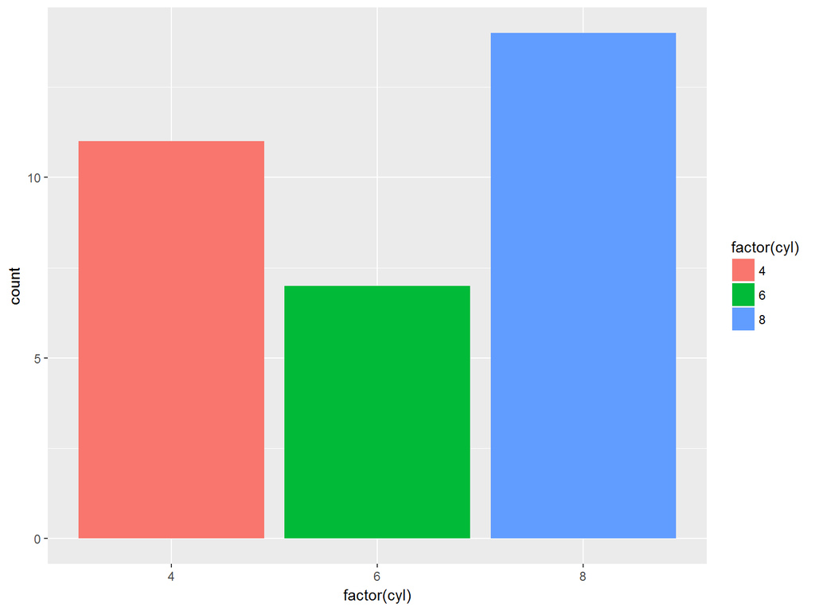

# Things to Avoid

Compare:

| mpg | cyl | disp | hp | drat | wt | qsec | vs | am | gear | carb |
| --- | --- | --- | --- | --- | --- | --- | --- | --- | --- | --- |
| 21.4 | 4 | 121 | 109 | 4.11 | 2.78 | 18.6 | 1 | 1 | 4 | 2 |
| 21.5 | 4 | 120.1 | 97 | 3.7 | 2.465 | 20.01 | 1 | 0 | 3 | 1 |
| 22.8 | 4 | 140.8 | 95 | 3.92 | 3.15 | 22.9 | 1 | 0 | 4 | 2 |
| 22.8 | 4 | 108 | 93 | 3.85 | 2.32 | 18.61 | 1 | 1 | 4 | 1 |
| 24.4 | 4 | 146.7 | 62 | 3.69 | 3.19 | 20 | 1 | 0 | 4 | 2 |
| 26 | 4 | 120.3 | 91 | 4.43 | 2.14 | 16.7 | 0 | 1 | 5 | 2 |
| 27.3 | 4 | 79 | 66 | 4.08 | 1.935 | 18.9 | 1 | 1 | 4 | 1 |
| 30.4 | 4 | 75.7 | 52 | 4.93 | 1.615 | 18.52 | 1 | 1 | 4 | 2 |
| 30.4 | 4 | 95.1 | 113 | 3.77 | 1.513 | 16.9 | 1 | 1 | 5 | 2 |
| 32.4 | 4 | 78.7 | 66 | 4.08 | 2.2 | 19.47 | 1 | 1 | 4 | 1 |
| 33.9 | 4 | 71.1 | 65 | 4.22 | 1.835 | 19.9 | 1 | 1 | 4 | 1 |
| 17.8 | 6 | 167.6 | 123 | 3.92 | 3.44 | 18.9 | 1 | 0 | 4 | 4 |
| 18.1 | 6 | 225 | 105 | 2.76 | 3.46 | 20.22 | 1 | 0 | 3 | 1 |
| 19.2 | 6 | 167.6 | 123 | 3.92 | 3.44 | 18.3 | 1 | 0 | 4 | 4 |
| 19.7 | 6 | 145 | 175 | 3.62 | 2.77 | 15.5 | 0 | 1 | 5 | 6 |
| 21 | 6 | 160 | 110 | 3.9 | 2.875 | 17.02 | 0 | 1 | 4 | 4 |
| 21 | 6 | 160 | 110 | 3.9 | 2.62 | 16.46 | 0 | 1 | 4 | 4 |
| 21.4 | 6 | 258 | 110 | 3.08 | 3.215 | 19.44 | 1 | 0 | 3 | 1 |
| 10.4 | 8 | 472 | 205 | 2.93 | 5.25 | 17.98 | 0 | 0 | 3 | 4 |
| 10.4 | 8 | 460 | 215 | 3 | 5.424 | 17.82 | 0 | 0 | 3 | 4 |
| 13.3 | 8 | 350 | 245 | 3.73 | 3.84 | 15.41 | 0 | 0 | 3 | 4 |
| 14.3 | 8 | 360 | 245 | 3.21 | 3.57 | 15.84 | 0 | 0 | 3 | 4 |
| 14.7 | 8 | 440 | 230 | 3.23 | 5.345 | 17.42 | 0 | 0 | 3 | 4 |
| 15 | 8 | 301 | 335 | 3.54 | 3.57 | 14.6 | 0 | 1 | 5 | 8 |
| 15.2 | 8 | 304 | 150 | 3.15 | 3.435 | 17.3 | 0 | 0 | 3 | 2 |
| 15.2 | 8 | 275.8 | 180 | 3.07 | 3.78 | 18 | 0 | 0 | 3 | 3 |
| 15.5 | 8 | 318 | 150 | 2.76 | 3.52 | 16.87 | 0 | 0 | 3 | 2 |
| 15.8 | 8 | 351 | 264 | 4.22 | 3.17 | 14.5 | 0 | 1 | 5 | 4 |
| 16.4 | 8 | 275.8 | 180 | 3.07 | 4.07 | 17.4 | 0 | 0 | 3 | 3 |
| 17.3 | 8 | 275.8 | 180 | 3.07 | 3.73 | 17.6 | 0 | 0 | 3 | 3 |
| 18.7 | 8 | 360 | 175 | 3.15 | 3.44 | 17.02 | 0 | 0 | 3 | 2 |
| 19.2 | 8 | 400 | 175 | 3.08 | 3.845 | 17.05 | 0 | 0 | 3 | 2 |

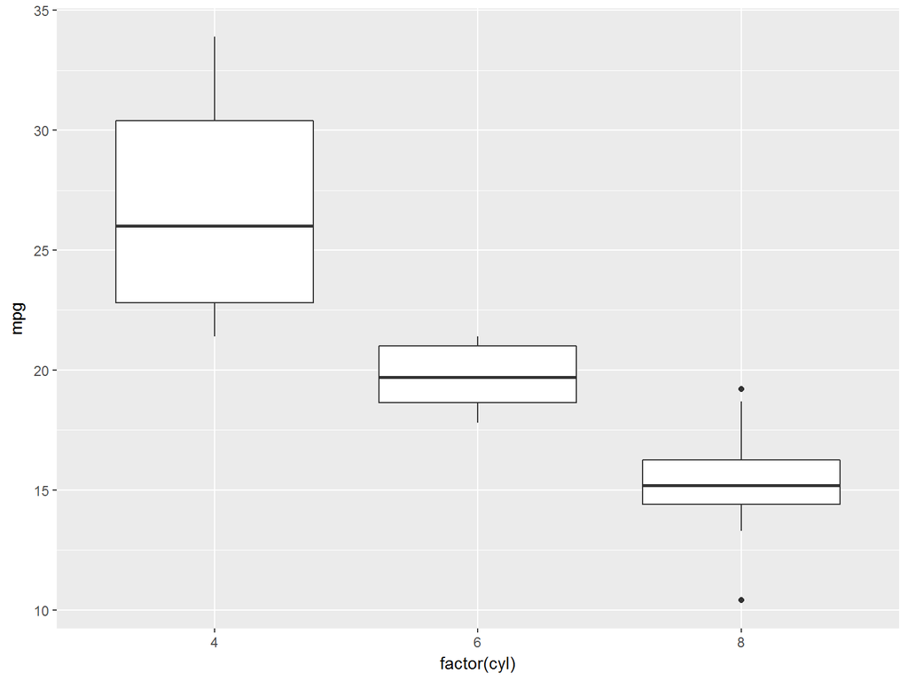

# Table Generating Packages and Functions

# `knitr::kable`

- Basic tables that adapt to Markdown, HTML, or LaTeX output based on your document type.
- Very little in the way of customization (by design)
- Generally adequate for most tables unless you require some customization

```r
tidy(fit) %>%
  knitr::kable()
```

| term | estimate | std.error | statistic | p.value |
| --- | --- | --- | --- | --- |
| (Intercept) | -0.1062751 | 0.2010637 | -0.5285643 | 0.5971078 |
| age30-44 | -0.2209191 | 0.2490994 | -0.8868713 | 0.3751482 |
| age45-60 | 0.4834246 | 0.2437668 | 1.9831439 | 0.0473514 |
| age> 60 | 0.9327496 | 0.2803337 | 3.3272826 | 0.0008770 |
| genderMale | -0.7125027 | 0.1812105 | -3.9319054 | 0.0000843 |

# `xtable` package

- Widely accepted as the standard for table generation.
- works with many object types
- Can produce HTML and LaTeX, but not markdown
- Extremely flexible, but requires knowledge of HTML and/or LaTeX
- If you use customizations, you are limited to either HTML *or* LaTeX.
- Does not inherently change output type based on your document

```r
tidy(fit) %>%
  xtable() %>%
  print(type = "html")
```

|  | term | estimate | std.error | statistic | p.value |
| --- | --- | --- | --- | --- | --- |
| 1 | (Intercept) | -0.11 | 0.20 | -0.53 | 0.60 |
| 2 | age30-44 | -0.22 | 0.25 | -0.89 | 0.38 |
| 3 | age45-60 | 0.48 | 0.24 | 1.98 | 0.05 |
| 4 | age> 60 | 0.93 | 0.28 | 3.33 | 0.00 |
| 5 | genderMale | -0.71 | 0.18 | -3.93 | 0.00 |

# `pixiedust` (My personal favorite)

- Transitions between markdown, HTML, and LaTeX output based on your document type.
- Similar flexibility as `xtable`, but not quite as flexible. Covers just about everything that is used on a regular basis
- Applies `tidy` for you
- Preserves the values of the original data
- Verbose

```r
dust(fit) %>%
  medley_model() %>%
  sprinkle_print_method("html") # not normally necessary
```

| term | estimate | std.error | statistic | p.value |
| --- | --- | --- | --- | --- |
| (Intercept) | -0.11 | 0.2 | -0.53 | 0.6 |
| age30-44 | -0.22 | 0.25 | -0.89 | 0.38 |
| age45-60 | 0.48 | 0.24 | 1.98 | 0.047 |
| age> 60 | 0.93 | 0.28 | 3.33 | < 0.001 |
| genderMale | -0.71 | 0.18 | -3.93 | < 0.001 |

# `htmlTable`

- Only does HTML Output
- Probably the most flexible and widely used package for HTML Output

```r
library(htmlTable)
tidy(fit) %>%
  htmlTable()
```

|  | term | estimate | std.error | statistic | p.value |
| --- | --- | --- | --- | --- | --- |
| 1 | (Intercept) | -0.106275072655955 | 0.201063673467902 | -0.528564264359374 | 0.597107755687042 |
| 2 | age30-44 | -0.220919077710373 | 0.249099371366615 | -0.886871277508093 | 0.375148207080116 |
| 3 | age45-60 | 0.483424579656973 | 0.243766773509928 | 1.98314385794373 | 0.0473513628549916 |
| 4 | age> 60 | 0.932749581706666 | 0.280333742283103 | 3.32728259577366 | 0.000876973890241549 |
| 5 | genderMale | -0.712502658144994 | 0.1812105272986 | -3.93190544041036 | 8.42752165909661e-05 |

# `condformat`

- Specializes in conditional formatting (colored background cells)
- Produces HTML, LaTeX, and Excel output
- Overloads the `+` operator (much like `ggplot`) which has become a less-favored practice
- Some versions require `rJava`, which requires Java on your machine, which can be a pain to manage.

```r
library(condformat)
data(iris)
library(condformat)
condformat(iris[c(1:5,70:75, 120:125),]) +
  rule_fill_discrete(Species) +
  rule_fill_discrete(Sepal.Width, Sepal.Length,
                     expression = Sepal.Width > Sepal.Length - 2.25,
                     colours = c("TRUE" = "#7D00FF")) +
  rule_fill_gradient2(Petal.Length)
```

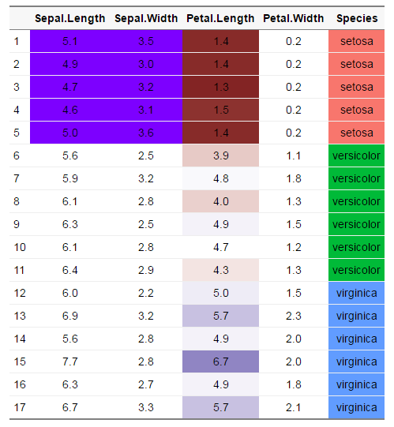